# Posterior distributions for the strongest kelp-associated fish

- Show All Code
- Hide All Code
- View Source

A reproducible link to the FishKelp v7 evidence-hierarchy model

Author

AJ Smit

Published

August 19, 2026

# Purpose

This document identifies the fish with the strongest modelled relationship with kelp in the FishKelp v7 analysis. It then plots that species’ trophic and habitat posterior distributions. The two routes remain separate throughout.

The document does **not** convert the evidence hierarchy into a percentage of “kelp dependence”. The FishKelp response is ordinal: None, Co-occurrence, Use, Selection, Contribution and Dependence. The fitted v7 data contain observations from None to Contribution; Dependence is defined by the review instrument but is not represented by a qualifying record. Consequently, the posterior quantity shown here is the continuous **expected evidence level** on the observed 0–4 scale.

# Does the proposed framework make sense?

The ecological structure in `Bayesian_framework_Read_Me.qmd` is useful. In particular:

- trophic and habitat evidence should be analysed separately;
- uncertainty and the specificity of each record should affect inference; and
- the ordered claims from co-occurrence through dependence should not be treated as synonyms.

The code in `Posteriors.qmd` is not yet a valid implementation of that idea. It draws simulated observations from a selected prior and then fits a Beta density back to those same observations. This is circular. The optimisation step does not combine a stated prior with a data likelihood, does not use the FishKelp records, and does not use Stan despite loading `rstan`. It also optimises the two Beta shape parameters without constraining them to be positive.

A Beta distribution would be appropriate for an unknown continuous proportion with a compatible sampling model. The FishKelp response is instead an ordered evidence category. Assigning a high Beta prior merely because a fish occurs in the west or at kelp depth also risks treating access to kelp as evidence of use or dependence. That contradicts the evidence hierarchy. In the v7 analysis, region and species traits are predictors, while the highest level supported by each source is the response.

# Analysis inputs

The repository contains a dated copy of the model input, posterior summary, evidence records and posterior draws used here. The paths below are relative to this document, so the report will work from a fresh clone without access to my FishKelp directory.

```r
qmd_path <- normalizePath(knitr::current_input(dir = TRUE), mustWork = TRUE)
analysis_dir <- dirname(qmd_path)
repo_root <- dirname(analysis_dir)
bundle_dir <- file.path(repo_root, "data", "fishkelp_v7")

model_data_path <- file.path(
  bundle_dir, "model", "tdr_model_data_v7.rds"
)
estimate_path <- file.path(
  bundle_dir, "fishkelp_posterior_estimates_v7.csv"
)
evidence_path <- file.path(
  bundle_dir, "fishkelp_model_records_v7.csv"
)

output_dir <- file.path(analysis_dir, "posterior_outputs")
dir.create(output_dir, recursive = TRUE, showWarnings = FALSE)

estimates <- read.csv(
  estimate_path,
  stringsAsFactors = FALSE,
  na.strings = c("NA", "")
)
estimates$species <- estimates$accepted_name
fish_estimates <- estimates[
  estimates$modelled_v7 &
    estimates$n_T > 0 & estimates$n_H > 0,
]
fish_estimates$mean_route_reach <- rowMeans(
  fish_estimates[, c("T_reach", "H_reach")]
)

# Match the ordering used in the FishKelp summary.
fish_estimates <- fish_estimates[
  order(-fish_estimates$T_reach, -fish_estimates$H_reach),
]
selected_species <- fish_estimates$species[1]
species_slug <- gsub("[^A-Za-z0-9]+", "_", selected_species)

top_habitat_fish <- fish_estimates$species[which.max(fish_estimates$H_reach)]
```

## Selection result

The FishKelp summary ranks evidence-bearing fish by trophic reach. That rule selects *Pachymetopon blochii*. It is also the fish with the highest unweighted mean across the two routes. The habitat-only leader is *Poroderma africanum*, so *Pachymetopon blochii* should not be described as the highest-ranked fish under every possible definition of “strongest”.

```r
ranking_table <- head(
  fish_estimates[, c(
    "species", "n_T", "T_reach", "T_reach_lo", "T_reach_hi",
    "n_H", "H_reach", "H_reach_lo", "H_reach_hi", "mean_route_reach"
  )],
  10
)
names(ranking_table) <- c(
  "Species", "T records", "T mean", "T 2.5%", "T 97.5%",
  "H records", "H mean", "H 2.5%", "H 97.5%", "Mean of routes"
)
knitr::kable(
  ranking_table,
  digits = 3,
  caption = "The ten fish with the highest trophic expected reach, matching the FishKelp summary order."
)
```

The ten fish with the highest trophic expected reach, matching the FishKelp summary order.

|  | Species | T records | T mean | T 2.5% | T 97.5% | H records | H mean | H 2.5% | H 97.5% | Mean of routes |
| --- | --- | --- | --- | --- | --- | --- | --- | --- | --- | --- |
| 15 | Pachymetopon blochii | 7 | 0.468 | 0.068 | 1.133 | 39 | 0.409 | 0.191 | 0.654 | 0.438 |
| 4 | Pachymetopon grande | 3 | 0.053 | 0.000 | 0.398 | 39 | 0.307 | 0.031 | 0.723 | 0.180 |
| 5 | Oplegnathus conwayi | 1 | 0.043 | 0.000 | 0.320 | 19 | 0.234 | 0.021 | 0.632 | 0.138 |
| 3 | Diplodus capensis | 14 | 0.038 | 0.000 | 0.249 | 131 | 0.279 | 0.089 | 0.526 | 0.158 |
| 6 | Rhabdosargus holubi | 14 | 0.036 | 0.000 | 0.286 | 115 | 0.027 | 0.000 | 0.149 | 0.032 |
| 17 | Pterogymnus laniarius | 4 | 0.035 | 0.000 | 0.289 | 39 | 0.155 | 0.015 | 0.436 | 0.095 |
| 21 | Cheimerius nufar | 7 | 0.032 | 0.000 | 0.268 | 63 | 0.026 | 0.000 | 0.164 | 0.029 |
| 28 | Epinephelus marginatus | 4 | 0.025 | 0.000 | 0.220 | 54 | 0.180 | 0.006 | 0.550 | 0.102 |
| 26 | Sparodon durbanensis | 4 | 0.025 | 0.000 | 0.225 | 49 | 0.115 | 0.001 | 0.454 | 0.070 |
| 25 | Poroderma africanum | 8 | 0.024 | 0.000 | 0.182 | 72 | 0.437 | 0.222 | 0.668 | 0.230 |

The coded evidence for *Pachymetopon blochii* has the following distribution across observed levels. These are input records, not posterior probabilities.

```r
evidence <- read.csv(evidence_path, stringsAsFactors = FALSE, check.names = FALSE)
names(evidence)[8] <- "level"
selected_evidence <- evidence[evidence$species == selected_species,]
evidence_counts <- as.data.frame(
  table(
    Route = factor(selected_evidence$route, levels = c("T", "H")),
    Level = factor(selected_evidence$level, levels = 0:4)
  )
)
evidence_counts <- evidence_counts[evidence_counts$Freq > 0,]
evidence_counts$Route <- c(T = "Trophic", H = "Habitat")[
  as.character(evidence_counts$Route)
]
evidence_counts$Level <- c(
  "0: None", "1: Co-occurrence", "2: Use",
  "3: Selection", "4: Contribution"
)[as.integer(evidence_counts$Level) + 1]
names(evidence_counts)[3] <- "Records"
knitr::kable(evidence_counts, caption = "Coded records for the selected fish.")
```

Coded records for the selected fish.

| Route | Level | Records |
| --- | --- | --- |
| Trophic | 1: Co-occurrence | 3 |
| Habitat | 1: Co-occurrence | 29 |
| Trophic | 2: Use | 1 |
| Habitat | 2: Use | 8 |
| Trophic | 3: Selection | 3 |
| Habitat | 3: Selection | 2 |

# Load the posterior draws

The repository includes the 180,000 retained draws from the FishKelp v7 fit. Keeping the model fit separate makes this report quicker and easier to follow. The full fitting command appears near the end of the document.

```r
posterior_draws_path <- file.path(
  output_dir, "strongest_fish_posterior_draws_v7.rds"
)
posterior_fit <- readRDS(posterior_draws_path)
posterior_draws <- posterior_fit$draws
```

# Posterior summaries

The summary below is calculated directly from the retained draws.

```r
summarise_route <- function(values, route) {
  data.frame(
    Species = selected_species,
    Route = route,
    Mean = mean(values),
    Median = median(values),
    `2.5%` = unname(quantile(values, 0.025)),
    `97.5%` = unname(quantile(values, 0.975)),
    check.names = FALSE
  )
}

posterior_summary <- rbind(
  summarise_route(posterior_draws$Trophic, "Trophic"),
  summarise_route(posterior_draws$Habitat, "Habitat")
)

summary_csv_path <- file.path(
  output_dir, paste0(species_slug, "_posterior_summary_v7.csv")
)
write.csv(posterior_summary, summary_csv_path, row.names = FALSE)

knitr::kable(
  posterior_summary,
  digits = 3,
  caption = "Posterior expected evidence reach in the West (kelp) context."
)
```

Posterior expected evidence reach in the West (kelp) context.

| Species | Route | Mean | Median | 2.5% | 97.5% |
| --- | --- | --- | --- | --- | --- |
| Pachymetopon blochii | Trophic | 0.468 | 0.418 | 0.068 | 1.133 |
| Pachymetopon blochii | Habitat | 0.409 | 0.404 | 0.191 | 0.654 |

# Prior-predictive reference

Zoë’s existing figures compare a blue dashed prior curve with a red posterior curve. The same comparison is useful here, provided that “prior” has a precise meaning. The code below samples the prior-predictive expected reach implied by the actual FishKelp v7 priors. It includes the priors on route-specific coefficients, the species effect and the ordered cut-points. It does not reuse a posterior as a prior and does not simulate observations from a selected Beta curve.

```r
model_data <- readRDS(model_data_path)
species_index <- match(selected_species, model_data$species_lab)

set.seed(20260819)
n_prior_draws <- 50000L
nu0 <- 40
tau0 <- 0.7
cut_sd <- 5

# Under Sigma ~ inverse-Wishart(nu0, S0) and u | Sigma ~ N(0, Sigma),
# a single species effect has a multivariate t marginal distribution.
prior_df <- nu0 - model_data$D + 1
s0_diagonal <- tau0^2 * (nu0 - model_data$D - 1)
species_effect_scale <- sqrt(s0_diagonal / prior_df)

draw_prior_location <- function(route_index) {
  coefficient_draws <- matrix(
    rnorm(
      n_prior_draws * model_data$P,
      sd = rep(model_data$prior_scale, each = n_prior_draws)
    ),
    nrow = n_prior_draws,
    ncol = model_data$P
  )
  fixed_location <- drop(
    coefficient_draws %*% model_data$X_ref[species_index,]
  )
  species_effect <- species_effect_scale * rnorm(n_prior_draws) /
    sqrt(rchisq(n_prior_draws, df = prior_df) / prior_df)
  fixed_location + species_effect
}

draw_prior_cutpoints <- function() {
  free_cutpoints <- matrix(
    abs(rnorm(
      n_prior_draws * (model_data$C - 2L),
      sd = cut_sd
    )),
    nrow = n_prior_draws
  )
  free_cutpoints <- t(apply(free_cutpoints, 1, sort))
  cbind(0, free_cutpoints)
}

expected_reach <- function(location, cutpoints) {
  rowSums(1 - pnorm(cutpoints - location))
}

prior_draws <- data.frame(
  Trophic = expected_reach(
    draw_prior_location(1), draw_prior_cutpoints()
  ),
  Habitat = expected_reach(
    draw_prior_location(2), draw_prior_cutpoints()
  )
)
```

# Prior and posterior distributions

The next figure follows the presentation used in `Posteriors_files/figure-html`: blue dashed curves are prior distributions and red solid curves are posterior distributions. Unlike the earlier example figures, both curves here are generated by the fitted FishKelp model and use the evidence-reach scale.

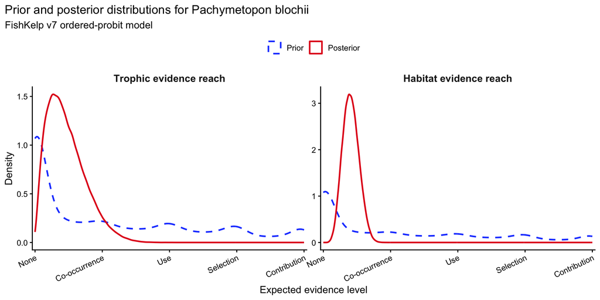

Prior-predictive and posterior distributions of trophic and habitat evidence reach for Pachymetopon blochii.

```r
# Convert the wide draws into the long form expected by ggplot2.
long_draws <- function(draws, distribution) {
  long <- stack(draws[c("Trophic", "Habitat")])
  data.frame(
    Route = long$ind,
    Distribution = distribution,
    Reach = long$values
  )
}

comparison_long <- rbind(
  long_draws(prior_draws, "Prior"),
  long_draws(posterior_draws, "Posterior")
)
comparison_long$Route <- factor(
  comparison_long$Route,
  levels = c("Trophic", "Habitat")
)
comparison_long$Distribution <- factor(
  comparison_long$Distribution,
  levels = c("Prior", "Posterior")
)

level_labels <- c("None", "Co-occurrence", "Use", "Selection", "Contribution")
comparison_colours <- c(Prior = "#1F4AFF", Posterior = "#E31A1C")
comparison_linetypes <- c(Prior = "dashed", Posterior = "solid")

p_prior_posterior <- ggplot2::ggplot(
  comparison_long,
  ggplot2::aes(
    x = Reach,
    colour = Distribution,
    linetype = Distribution
  )
) +
  ggplot2::geom_density(linewidth = 0.9, adjust = 1.1) +
  ggplot2::facet_wrap(
    ~Route,
    nrow = 1,
    scales = "free_y",
    labeller = ggplot2::labeller(
      Route = c(
        Trophic = "Trophic evidence reach",
        Habitat = "Habitat evidence reach"
      )
    )
  ) +
  ggplot2::scale_colour_manual(values = comparison_colours) +
  ggplot2::scale_linetype_manual(values = comparison_linetypes) +
  ggplot2::scale_x_continuous(
    breaks = 0:4,
    labels = level_labels,
    limits = c(0, 4),
    expand = ggplot2::expansion(mult = c(0.01, 0.01))
  ) +
  ggplot2::labs(
    title = paste("Prior and posterior distributions for", selected_species),
    subtitle = "FishKelp v7 ordered-probit model",
    x = "Expected evidence level",
    y = "Density",
    colour = NULL,
    linetype = NULL
  ) +
  ggplot2::theme_classic(base_size = 12) +
  ggplot2::theme(
    strip.background = ggplot2::element_blank(),
    strip.text = ggplot2::element_text(face = "bold", size = 12),
    axis.text.x = ggplot2::element_text(angle = 25, hjust = 1),
    legend.position = "top",
    plot.title.position = "plot"
  )

prior_posterior_png <- file.path(
  output_dir, paste0(species_slug, "_prior_vs_posterior_v7.png")
)
prior_posterior_pdf <- file.path(
  output_dir, paste0(species_slug, "_prior_vs_posterior_v7.pdf")
)
ggplot2::ggsave(
  prior_posterior_png, p_prior_posterior,
  width = 10, height = 5, dpi = 300
)
ggplot2::ggsave(
  prior_posterior_pdf, p_prior_posterior,
  width = 10, height = 5
)

for (route_name in levels(comparison_long$Route)) {
  single_comparison <- ggplot2::ggplot(
    comparison_long[comparison_long$Route == route_name,],
    ggplot2::aes(
      x = Reach,
      colour = Distribution,
      linetype = Distribution
    )
  ) +
    ggplot2::geom_density(linewidth = 0.9, adjust = 1.1) +
    ggplot2::scale_colour_manual(values = comparison_colours) +
    ggplot2::scale_linetype_manual(values = comparison_linetypes) +
    ggplot2::scale_x_continuous(
      breaks = 0:4,
      labels = level_labels,
      limits = c(0, 4),
      expand = ggplot2::expansion(mult = c(0.01, 0.01))
    ) +
    ggplot2::labs(
      title = paste(route_name, "reach:", selected_species),
      subtitle = "Blue dashed: prior; red solid: posterior",
      x = "Expected evidence level",
      y = "Density",
      colour = NULL,
      linetype = NULL
    ) +
    ggplot2::theme_classic(base_size = 12) +
    ggplot2::theme(
      axis.text.x = ggplot2::element_text(angle = 25, hjust = 1),
      legend.position = "top"
    )

  route_comparison_file <- file.path(
    output_dir,
    paste0(
      species_slug,
      "_",
      tolower(route_name),
      "_prior_vs_posterior_v7.png"
    )
  )
  ggplot2::ggsave(
    route_comparison_file, single_comparison,
    width = 7.5, height = 4.8, dpi = 300
  )
}

p_prior_posterior
```

# Interpretation

For *Pachymetopon blochii*, the trophic posterior mean is 0.468 (95% credible interval 0.068–1.133). The habitat posterior mean is 0.409 (95% credible interval 0.191–0.654).

# Reproduction and outputs

Render from the repository root with:

```bash
quarto render Bayesian_framework/FishKelp_strongest_fish_posteriors.qmd
```

Run the full model after a data change with:

```bash
Rscript R/run_fishkelp_v7_suite.R
```

The model script updates the retained focal draws. Render this report again to update the figures. The HTML report is written beside this `.qmd`. The combined PNG and PDF, route-specific PNGs, posterior draws and numerical summary are written to `Bayesian_framework/posterior_outputs/`.